# How does a bike-share navigate speedy success

Dan Xu

2025-06-28

## Introduction

Cyclistic is a bike-share program based in Chicago, offering more than 5,800 bicycles and over 600 docking stations. The program includes not only traditional bikes but also adaptive options such as reclining bikes, hand tricycles, and cargo bikes, making it accessible to a broader range of users. While Cyclistic has successfully attracted both casual riders and annual members, the marketing team—led by Director Lily Moreno—believes that increasing the number of annual memberships is critical for long-term growth.

To support this initiative, this project aims to analyze historical trip data to better understand the behavioral differences between casual riders and annual members. The goal is to uncover actionable insights that can inform targeted marketing strategies designed to convert casual riders into loyal annual members.

## Business Task

This project aims to analyze the differences in bike usage patterns between casual riders and annual members. By identifying key trends, the goal is to support Cyclistic’s marketing team in designing strategies to **convert casual riders into annual members**, ultimately driving long-term growth and profitability.

## Data Sources

This analysis is based on the [Divvy 2019 Q1](https://docs.google.com/spreadsheets/d/1TTqD-Dfp35NbpngkcssNwkzXH9If-v6Wni9FKKSI9wo/edit?gid=740366725#gid=740366725) and [Divvy 2020 Q1](https://docs.google.com/spreadsheets/d/1c2UvCwKGVSd6bvyVhri3vX6Hr8Qt-FFb8dMm6lRTjLI/edit?gid=913890959#gid=913890959) bike-share trip datasets, provided by Motivate International Inc. The data includes trip-level records such as:

- start and end timestamps
- station names and IDs
- rider type (member vs. casual)
- bike type

All data was downloaded from the Divvy trip data portal and is publicly available under an open data license. These datasets were merged, cleaned, and processed in R to support the business question of understanding usage differences between rider types.

## Data Preparation

These steps ensured that the dataset was clean, consistent, and ready for descriptive and comparative analysis.

```r
library(tidyverse)
library(lubridate)

# Read two files
q1_2019 <- read_csv("/Users/doublenine_/Desktop/Marketing_Startegies/original_data/Divvy_2019_Q1.csv")
q1_2020 <- read_csv("/Users/doublenine_/Desktop/Marketing_Startegies/original_data/Divvy_2020_Q1.csv")
# Check the col names
colnames(q1_2019)
```

```
##  [1] "trip_id"           "start_time"        "end_time"
##  [4] "bikeid"            "tripduration"      "from_station_id"
##  [7] "from_station_name" "to_station_id"     "to_station_name"
## [10] "usertype"          "gender"            "birthyear"
```

```r
colnames(q1_2020)
```

```
##  [1] "ride_id"            "rideable_type"      "started_at"
##  [4] "ended_at"           "start_station_name" "start_station_id"
##  [7] "end_station_name"   "end_station_id"     "start_lat"
## [10] "start_lng"          "end_lat"            "end_lng"
## [13] "member_casual"
```

```r
# Rename the col
q1_2019 <- q1_2019 %>% rename(member_casual = usertype)

# Combine the two datasets
all_trips <- bind_rows(q1_2019, q1_2020)

# Create new variables
all_trips <- all_trips %>%
  mutate(
    started_at = ymd_hms(started_at),
    ended_at = ymd_hms(ended_at),
    ride_length = as.numeric(difftime(ended_at, started_at, units = "mins")),
    day_of_week = wday(started_at, label = TRUE)
  )

# Data Cleaning
all_trips <- all_trips %>%
  filter(ride_length > 0, ride_length < 1440)  # exclude extreme durations
```

## Data Analysis

To understand how **casual riders** and **annual members** use Cyclistic bikes differently, several dimensions of trip behavior were analyzed, including ride length, frequency by day of week, and usage patterns.

**1. Ride Duration**

Descriptive statistics show that **casual riders tend to have significantly longer ride durations than annual members.** This is likely because casual riders use the service for leisure, while members may be commuting or taking shorter, routine trips.

```r
all_trips %>%
  group_by(member_casual) %>%
  summarise(
    mean_ride = mean(ride_length),
    median_ride = median(ride_length),
    max_ride = max(ride_length),
    min_ride = min(ride_length)
  )
```

```
## # A tibble: 2 × 5
##   member_casual mean_ride median_ride max_ride min_ride
##   <chr>             <dbl>       <dbl>    <dbl>    <dbl>
## 1 casual             37.0       21.2     1436.   0.0167
## 2 member             11.5        8.57    1432.   0.0167
```

**2. Ride by day of week**

When analyzing usage frequency across the week, **annual members ride more consistently on weekdays, while casual riders ride more often on weekends,** suggesting a pattern of commuting vs. recreational use.

```r
all_trips %>%
  group_by(member_casual, day_of_week) %>%
  summarise(number_of_rides = n(), .groups = "drop") %>%
  arrange(member_casual, day_of_week)
```

```
## # A tibble: 14 × 3
##    member_casual day_of_week number_of_rides
##    <chr>         <ord>                 <int>
##  1 casual        Sun                   14820
##  2 casual        Mon                    4785
##  3 casual        Tue                    5225
##  4 casual        Wed                    5846
##  5 casual        Thu                    4819
##  6 casual        Fri                    5103
##  7 casual        Sat                    7445
##  8 member        Sun                   35959
##  9 member        Mon                   61916
## 10 member        Tue                   69692
## 11 member        Wed                   63969
## 12 member        Thu                   61236
## 13 member        Fri                   55477
## 14 member        Sat                   30095
```

**3. Visualization ride by day of week**

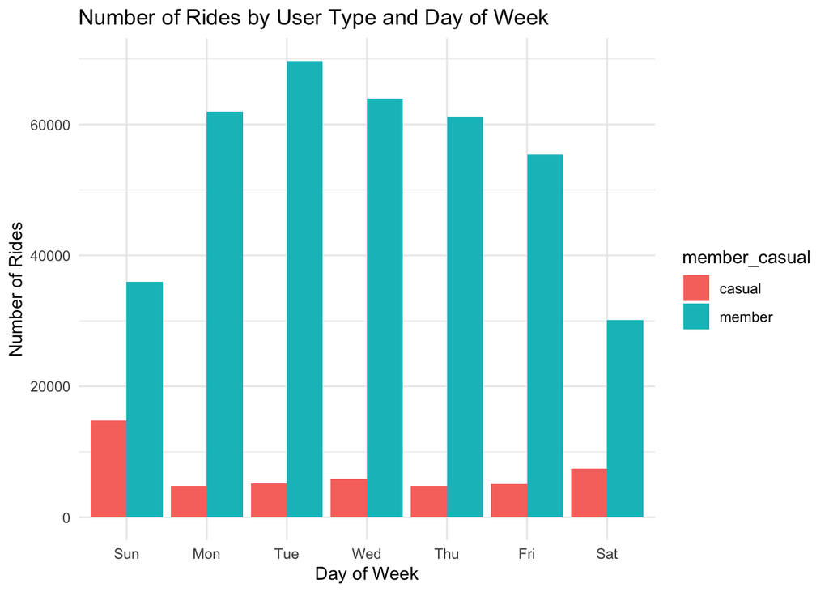

```r
library(ggplot2)

all_trips %>%
  group_by(member_casual, day_of_week) %>%
  summarise(number_of_rides = n(), .groups = "drop") %>%
  ggplot(aes(x = day_of_week, y = number_of_rides, fill = member_casual)) +
  geom_col(position = "dodge") +
  labs(title = "Number of Rides by User Type and Day of Week",
       x = "Day of Week", y = "Number of Rides") +
  theme_minimal()
```

**4. Visualization by duration**

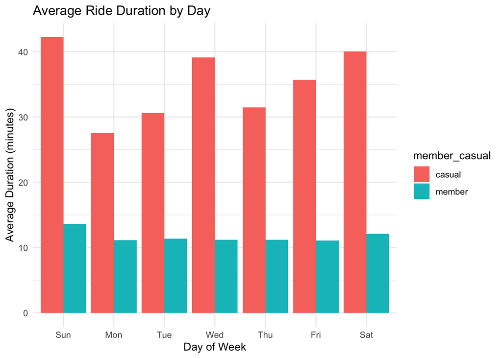

```r
all_trips %>%
  group_by(member_casual, day_of_week) %>%
  summarise(average_duration = mean(ride_length), .groups = "drop") %>%
  ggplot(aes(x = day_of_week, y = average_duration, fill = member_casual)) +
  geom_col(position = "dodge") +
  labs(title = "Average Ride Duration by Day",
       x = "Day of Week", y = "Average Duration (minutes)") +
  theme_minimal()
```

### Key Findings

- Casual riders tend to take longer rides than members.
- Annual members ride more consistently during weekdays, suggesting commute use.
- Casual riders are more active on weekends, indicating leisure behavior.

## Recommendations (with Pros & Cons)

**1. Launch Weekend Trial Membership Campaigns**

**Idea:** Offer short-term or discounted membership trials targeted specifically at casual riders during weekends, when their activity is highest.

- **Pros:**
  - Targets users when they are already active and likely to try new offers.
  - Low-risk, time-limited campaigns can generate quick insights and A/B test performance.
  - May convert leisure riders into habitual users.
- **Cons:**
  - May not lead to long-term retention if riders only associate value with weekends.
  - Requires coordination with pricing systems and digital promotions.
  - Could reduce revenue from single-ride passes if not managed carefully.

**2. Highlight Cost Savings and Convenience of Membership**

**Idea:** Use marketing materials (email, app, website banners) to show casual riders how annual memberships offer better value, especially for longer or repeated rides.

- **Pros:**
  - Appeals to rational decision-making by quantifying savings.
  - Builds awareness of pricing tiers many casual users may not fully understand.
  - Encourages behavior change based on logic rather than impulse.
- **Cons:**
  - Might not resonate with riders who prioritize flexibility or spontaneous use.
  - Requires clear, simple messaging—too much text or complexity may confuse.
  - Savings appeal may be less effective for tourists or infrequent users.

**3. Use Digital Retargeting to Convert Repeat Casual Riders**

**Idea:** Identify casual riders with multiple trips in a short time span and target them via email, app notifications, or web ads with member-exclusive offers.

- **Pros:**
  - High potential ROI by targeting users already engaged with the platform.
  - Personalized messaging increases conversion likelihood.
  - Efficient use of marketing budget by focusing on warm leads.
- **Cons:**
  - Requires access to user data that may be limited due to privacy or system design.
  - Needs coordination with app or CRM systems, which may not be set up for retargeting.
  - May miss one-time tourists or anonymous riders (e.g., kiosk users).

## Conclusion

This analysis explored the behavioral differences between Cyclistic’s annual members and casual riders. The findings reveal that casual riders are more likely to ride on weekends and take longer trips, while annual members show consistent, shorter rides throughout the week—suggesting commuting behavior.

These insights support the business goal of increasing annual memberships by informing more targeted marketing efforts. By focusing on casual riders’ motivations and riding patterns, Cyclistic can design effective campaigns that increase engagement and drive conversions.

## Appendix

### Key Variables Created:

- `ride_length`: calculated as the duration of each trip in minutes
- `day_of_week`: derived from `started_at` to understand usage patterns by day

### Packages Used:

- `tidyverse`
- `lubridate`
- `ggplot2`

### Data Source:

Trip data from [Divvy Bike Share System](https://divvy-tripdata.s3.amazonaws.com/index.html), provided by Motivate International Inc., used under open license. Data spans Q1 2019 and Q1 2020.